# Adoptable Pets Outcome Prediction

Florence Lourdes

2023-12-05

```r
library(yardstick)
library(dplyr)
```

```r
library(ggplot2)
library(corrr)
library(tidyverse)
library(tidymodels)
library(kableExtra)
library(patchwork)
library(ggplot2)
library(ranger)
library(tidytext)
library(tm)
library(slam)
data <- read_csv("C:/MAT434/MAT434 R Studio/aac_shelter_outcomes.csv")
```

# Statement of Purpose

The purpose of this project is to develop a predictive model that can assess the likelihood of an animal being adopted based on various features available in the Austin Animal Center Shelter dataset. By leveraging data science and machine learning techniques, my aim is to provide insights that can aid shelter staff in making informed decisions, ultimately increasing the adoption rates and improving the overall welfare of animals in the shelter.

# Introduction

Animal shelters play a crucial role in providing temporary care for animals in need. One of the challenges faced by these shelters is predicting which animals are more likely to be adopted, allowing them to allocate resources efficiently. In this project, we will utilize data science and machine learning methodologies to analyze the Austin Animal Center Shelter dataset. By understanding patterns in the data, I aim to create a predictive model that can assist shelter staff in identifying animals with higher chances of adoption, ultimately contributing to the well-being of these animals.

# Head of Data

The following table shows the top 6 rows of the data

```r
data %>%
  head()
```

```
## # A tibble: 6 × 12
##   age_upon_outcome animal_id animal_type breed         color date_of_birth
##   <chr>            <chr>     <chr>       <chr>         <chr> <dttm>
## 1 2 weeks          A684346   Cat         Domestic Sho… Oran… 2014-07-07 00:00:00
## 2 1 year           A666430   Dog         Beagle Mix    Whit… 2012-11-06 00:00:00
## 3 1 year           A675708   Dog         Pit Bull      Blue… 2013-03-31 00:00:00
## 4 9 years          A680386   Dog         Miniature Sc… White 2005-06-02 00:00:00
## 5 5 months         A683115   Other       Bat Mix       Brown 2014-01-07 00:00:00
## 6 4 months         A664462   Dog         Leonberger M… Brow… 2013-06-03 00:00:00
## # ℹ 6 more variables: datetime <dttm>, monthyear <dttm>, name <chr>,
## #   outcome_subtype <chr>, outcome_type <chr>, sex_upon_outcome <chr>
```

# Check for missing values

```r
colSums(is.na(data))
```

```
## age_upon_outcome        animal_id      animal_type            breed
##                0                0                0                0
##            color    date_of_birth         datetime        monthyear
##                0                0                0                0
##             name  outcome_subtype     outcome_type sex_upon_outcome
##            23886            42293               12                0
```

# Filter Data

```r
data <- data %>%
  filter(!is.na(outcome_subtype))
```

# Split data into training and test sets

The following code chunk is to set a seed to make sure that we get the same results for randomizationsplits. It also splits data into a training and test sets with a 8 to 2 ratio and marking outcome_type as prediction target. The last part is to extract the data from each training and test sets.

```r
set.seed(434)

my_data_split <- initial_split(data, prop = 0.8, strata = outcome_type)

train <- training(my_data_split)
test <- testing(my_data_split)
```

# Build cross-validation folds

K-fold cross-validation is a technique for evaluating predictive models. The dataset is divided into k subsets or folds. The model is trained and evaluated k times, using a different fold as the validation set each time. Performance metrics from each fold are averaged to estimate the model’s generalization performance.

```r
set.seed(456)
train_folds <- vfold_cv(train, v = 10)
```

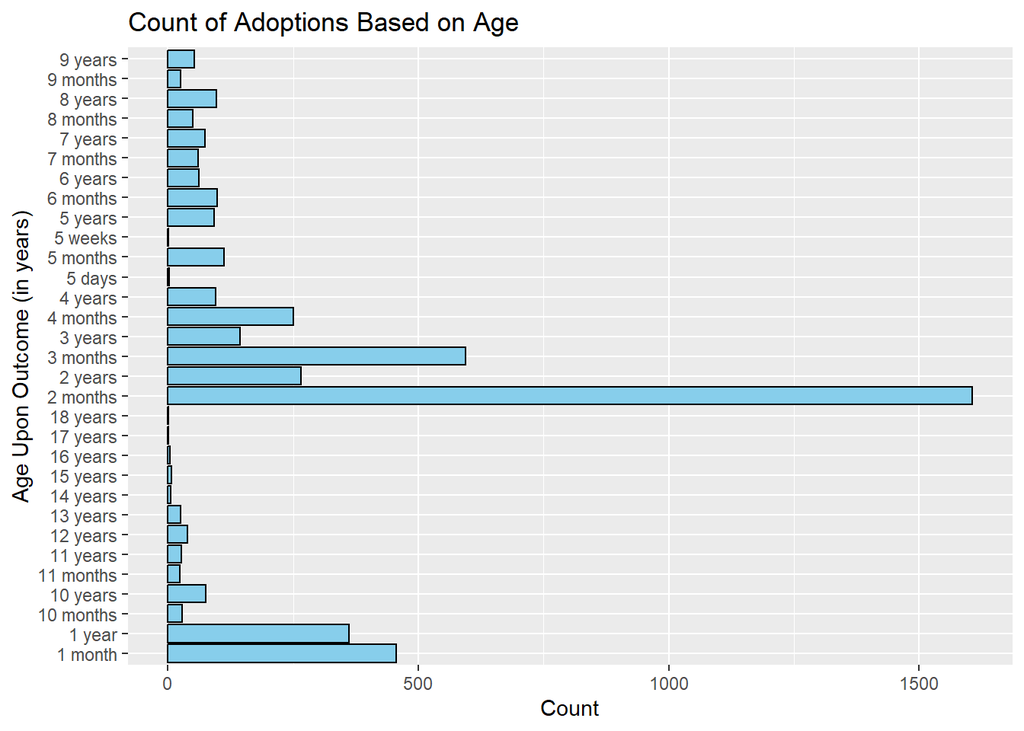

```r
adoption_data <- train[train$outcome_type == "Adoption", ]

# Box plot for adopted animals by age
ggplot(adoption_data, aes(x = age_upon_outcome)) +
  geom_bar(fill = "skyblue", color = "black") +
  labs(title = "Count of Adoptions Based on Age",
       x = "Age Upon Outcome (in years)",
       y = "Count") +
  coord_flip()
```

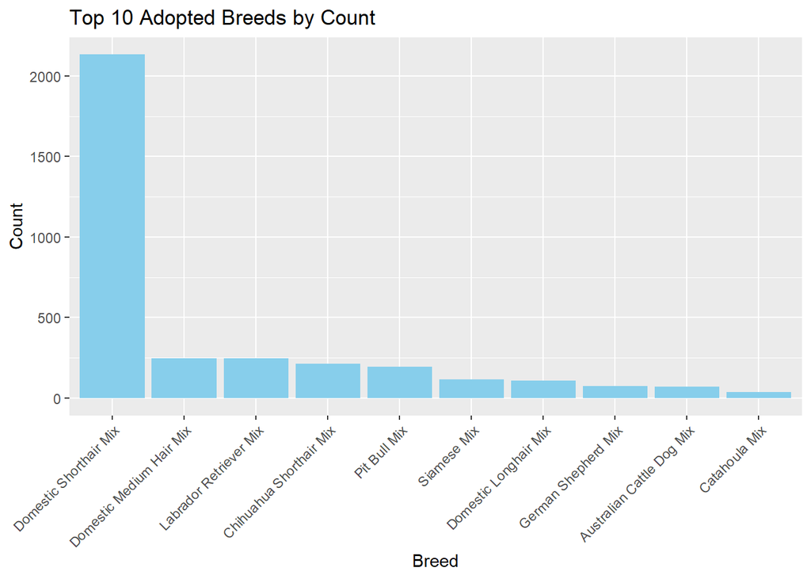

```r
# Bar plot for top 10 adopted breeds by count
top_breeds <- adoption_data %>%
  group_by(breed) %>%
  summarize(count = n()) %>%
  arrange(desc(count)) %>%
  head(10)

ggplot(top_breeds, aes(x = reorder(breed, -count), y = count)) +
  geom_bar(stat = "identity", fill = "skyblue") +
  labs(title = "Top 10 Adopted Breeds by Count",
       x = "Breed",
       y = "Count") +
  theme(axis.text.x = element_text(angle = 45, hjust = 1))
```

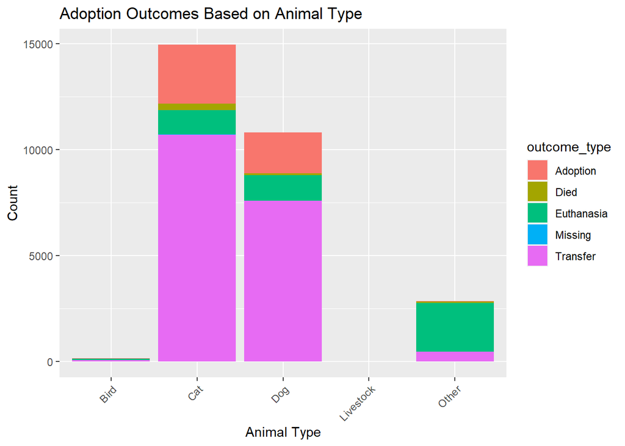

```r
# Bar plot for adoption outcomes based on animal type
ggplot(train, aes(x = animal_type, fill = outcome_type)) +
  geom_bar(position = "stack") +
  labs(title = "Adoption Outcomes Based on Animal Type",
       x = "Animal Type",
       y = "Count") +
  theme(axis.text.x = element_text(angle = 45, hjust = 1))
```

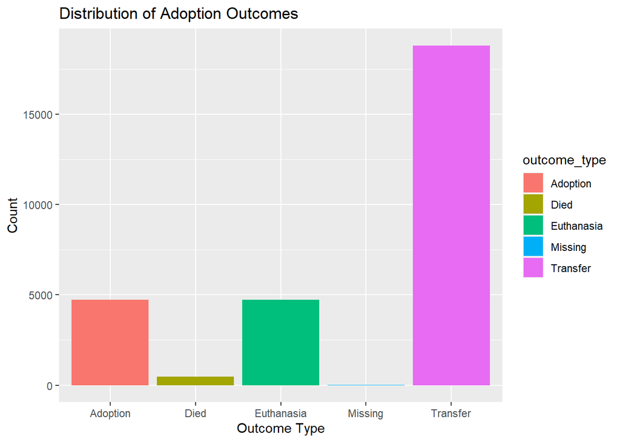

```r
# Target Variable Analysis
# A bar plot for the distribution of adoption outcomes
ggplot(train, aes(x = outcome_type, fill = outcome_type)) +
  geom_bar() +
  labs(title = "Distribution of Adoption Outcomes",
       x = "Outcome Type",
       y = "Count")
```

# Model Construction and Interpretation

In the following code, we will be using a training models called decision tree.The steps are to make a workflow, evaluate, and print the result.

```r
# Decision tree workflow
dt_spec <- decision_tree() %>%
  set_engine("rpart") %>%
  set_mode("classification")

dt_rec <- recipe(outcome_type ~ age_upon_outcome, data = train) %>%
  step_impute_median(all_numeric_predictors()) %>%
  step_novel(all_nominal_predictors()) %>%
  step_unknown(all_nominal_predictors()) %>%
  step_dummy(all_nominal_predictors())

dt_wf <- workflow() %>%
  add_model(dt_spec) %>%
  add_recipe(dt_rec)

# Evaluate workflows
dt_cv_results <- dt_wf %>%
  fit_resamples(train_folds)
```

```
## → A | warning: No observations were detected in `truth` for level(s): 'Missing'
##                Computation will proceed by ignoring those levels.
```

```
##
There were issues with some computations   A: x1

There were issues with some computations   A: x1
```

Here is the decision tree result

```r
# DT result
dt_cv_results %>%
  collect_metrics()
```

```
## # A tibble: 2 × 6
##   .metric  .estimator  mean     n std_err .config
##   <chr>    <chr>      <dbl> <int>   <dbl> <chr>
## 1 accuracy multiclass 0.670    10 0.00153 Preprocessor1_Model1
## 2 roc_auc  hand_till  0.539    10 0.00374 Preprocessor1_Model1
```

Next, we will be using hyperparameter tuning. Hyperparameter tuning allows data scientists to tweak model performance for optimal results. This process is an essential part of machine learning, and choosing appropriate hyperparameter values is crucial for success.

```r
# Grid
grid_depth <- tibble(
  "tree_depth" = c(2, 3, 4, 5, 8, 10, 12, 15, 20)
  )
```

The next step is to re-create the model workflows, setting the relevant hyperparameters to tune(). Then we’ll pipe these workflows into tune_grid() and read the results.

```r
# DT workflow
dt_spec <- decision_tree(tree_depth = tune()) %>%
  set_engine("rpart") %>%
  set_mode("classification")

dt_rec <- recipe(outcome_type ~ age_upon_outcome, data = train) %>%
  step_impute_median(all_numeric_predictors()) %>%
  step_novel(all_nominal_predictors()) %>%
  step_unknown(all_nominal_predictors()) %>%
  step_dummy(all_nominal_predictors())

dt_wf <- workflow() %>%
  add_model(dt_spec) %>%
  add_recipe(dt_rec)

# Hyperparameter tune
dt_tune_results <- dt_wf %>%
  tune_grid(
    grid = grid_depth,
    resamples = train_folds
  )
```

```
## → A | warning: No observations were detected in `truth` for level(s): 'Missing'
##                Computation will proceed by ignoring those levels.
```

```
##
There were issues with some computations   A: x1

There were issues with some computations   A: x1
```

Here is the tuned decission tree result:

```r
# DT results
dt_tune_results %>%
  collect_metrics() %>%
  filter(.metric == "accuracy") %>%
  select(tree_depth, mean, std_err) %>%
  arrange(-mean)
```

```
## # A tibble: 9 × 3
##   tree_depth  mean std_err
##        <dbl> <dbl>   <dbl>
## 1          2 0.670 0.00153
## 2          3 0.670 0.00153
## 3          4 0.670 0.00153
## 4          5 0.670 0.00153
## 5          8 0.670 0.00153
## 6         10 0.670 0.00153
## 7         12 0.670 0.00153
## 8         15 0.670 0.00153
## 9         20 0.670 0.00153
```

Result: The optimized decision tree model have the same accuracy as the normal decision tree classifier.

The final step is to fit, assess, and utilize our best model. Since the untuned decision tree classifier has the same accuracy as the tuned decision tree classifier, we will fit the untuned decision tree classifier because it is a simpler model.

```r
# Decision tree workflow
dt_spec <- decision_tree() %>%
  set_engine("rpart") %>%
  set_mode("classification")

dt_rec <- recipe(outcome_type ~ age_upon_outcome, data = train) %>%
  step_impute_median(all_numeric_predictors()) %>%
  step_novel(all_nominal_predictors()) %>%
  step_unknown(all_nominal_predictors()) %>%
  step_dummy(all_nominal_predictors())

dt_wf <- workflow() %>%
  add_model(dt_spec) %>%
  add_recipe(dt_rec)

# Fit model
dt_fit <- dt_wf %>%
  fit(train)

# Enter test data
dt_fit %>%
  augment(test) %>%
  mutate(outcome_type = as.factor(outcome_type)) %>%
  accuracy(outcome_type, .pred_class)
```

```
## # A tibble: 1 × 3
##   .metric  .estimator .estimate
##   <chr>    <chr>          <dbl>
## 1 accuracy multiclass     0.668
```

# Executive Summary

This project aimed to predict animal adoption outcomes using a basic decision tree model, focusing on a single variable for simplicity. The dataset, sourced from the Austin Animal Center Shelter, contained information about various factors influencing animal outcomes. The model achieved a 66% accuracy rate in its predictions.

The decision to use a basic decision tree with a single variable was deliberate, serving as an initial exploration into the predictive capabilities of the chosen feature. This simplicity allowed for a clear understanding of the model’s performance and potential areas for improvement.

# Conclusions

In conclusion, the project successfully implemented a basic decision tree model to predict animal adoption outcomes using a single variable. The 66% accuracy achieved provides valuable insights into the model’s potential, but it is important to note that this represents an initial exploration. Future iterations could benefit from incorporating more features, exploring alternative algorithms, and conducting deeper hyperparameter tuning to enhance predictive accuracy.

The decision to focus on simplicity in this phase of the project was strategic, allowing for a foundational understanding of the predictive power of individual variables. This project lays the groundwork for future enhancements and serves as a stepping stone for more advanced analyses and model optimizations.

Moving forward, the exploration of additional features, algorithmic improvements, and rigorous hyperparameter tuning will be crucial in developing a more robust and accurate model for predicting animal adoption outcomes at the Austin Animal Center Shelter.

# References

https://agmath.github.io/ClassificationCourse.html